# Laboratory 4: Resampling Methods

Giorgio Paulon

The University of Texas at Austin

October 3, 2019

```r
library(reshape2)
library(ggplot2)
library(RColorBrewer)
library(tidyverse)
library(ISLR)
library(readr)
library(MASS)
library(latex2exp)
theme_set(theme_bw(base_size = 14))
cols <- brewer.pal(9, "Set1")
```

# Assessing model accuracy

We try to answer the question: **how to assess model accuracy**? Cross-validation can be used to estimate the test error associated with a given statistical learning method in order to evaluate its performance, or to select the appropriate level of flexibility.

First, we need to choose a measure of error for a model. In the regression setting, the most commonly-used measure is the mean squared error (MSE), given by

$$\text{MSE} = \dfrac{1}{n} \sum_{i=1}^{n} \{y_{i} - \hat{f}(\textbf{x}_{i})\}^{2}$$
where $\hat{f}(\textbf{x}_{i})$ is the prediction that $\hat{f}$ gives for the $i^{th}$ observation.

- The MSE is computed using the training data that was used to fit the model, and so should more accurately be referred to as the **training** MSE.
- The training error can be easily calculated by applying the statistical learning method to the observations used in its training.
- However, the training error rate often is quite different from the test error rate, and in particular the former can dramatically underestimate the latter (“optimism of the training error”). The reason is that we should not use the data twice, i.e. to build the model and to evaluate its performance.
- Moreover, we do not really care how well the method works on the training data. Rather, we are interested in the accuracy of the predictions that we obtain when we apply our method to previously unseen test data (future predictions).
- Given a data set, the use of a particular statistical learning method is warranted if it results in a low test error. The test error can be easily calculated if a designated test set is available. Unfortunately, this is usually not the case.

## Bias-variance tradeoff

Let us see how the bias-variance tradeoff works with a practical example: knn regression.

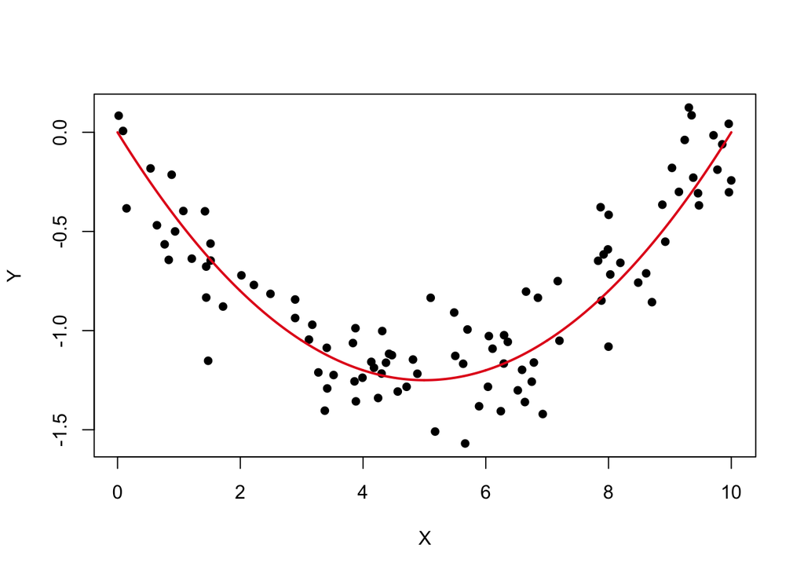

```r
# True function generating the data
fx <- function(x){
  return (0.05 * x^2 - 0.5*x)
}

library(caret) # loads the knn function

xmin <- 0
xmax <- 10
sigma <- 0.2
samp_size <- 100

xgrid <- seq(xmin, xmax, length.out = 1000)
X <- runif(samp_size, xmin, xmax)
Y <- rnorm(samp_size, fx(X), sigma)

plot(X, Y, pch = 16, xlab = 'X', ylab = 'Y')
lines(xgrid, fx(xgrid), col = cols[1], lwd = 2)
```

Let us try to see how the 1-nearest neighbour works.

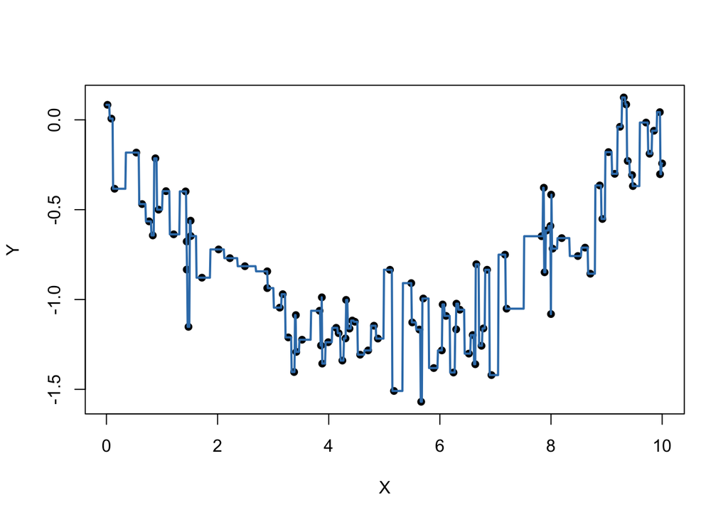

```r
fit <- knnreg(data.frame(X = X), Y, k = 1)
y_hat <- predict(fit, data.frame(X = xgrid))
plot(X, Y, pch = 16, xlab = 'X', ylab = 'Y')
lines(xgrid, y_hat, col = cols[2], lwd = 2)
```

This does not look right! It is basically fitting the noise that is inherent in the data. Low bias, high variance (with new data, prediction is going to be widely different).

How about if we increase $k$ to $10$?

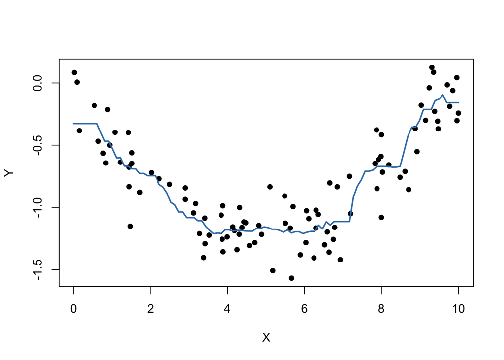

```r
fit <- knnreg(data.frame(X = X), Y, k = 10)
y_hat <- predict(fit, data.frame(X = xgrid))
plot(X, Y, pch = 16, xlab = 'X', ylab = 'Y')
lines(xgrid, y_hat, col = cols[2], lwd = 2)
```

This seems about right!

And if we keep increasing $k$ to $40$?

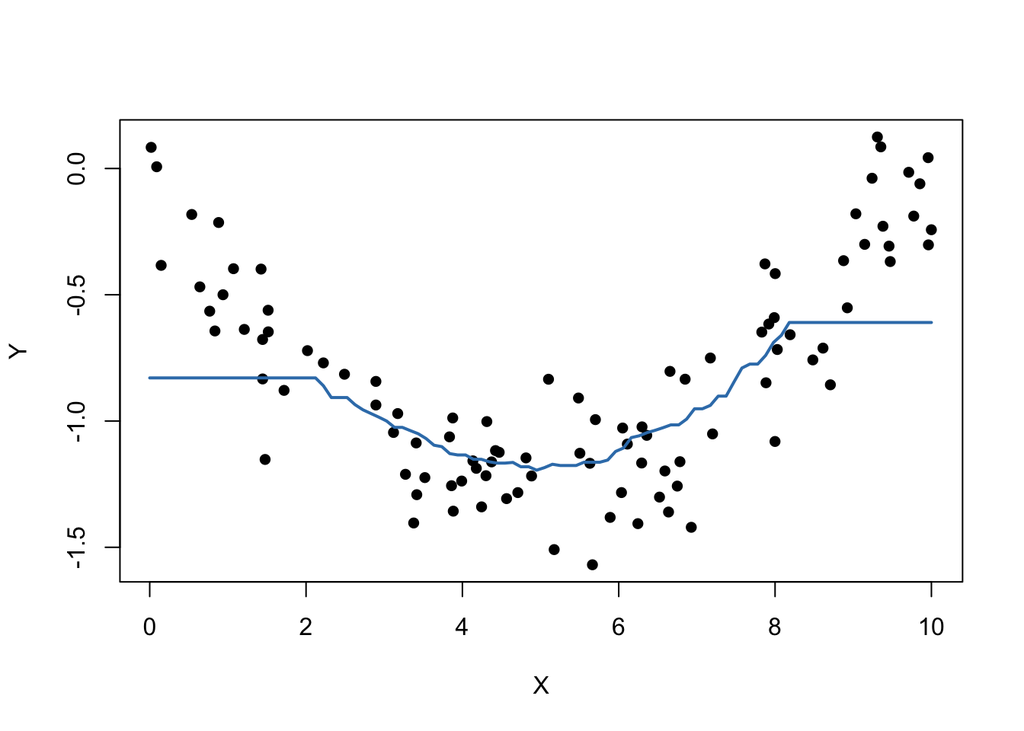

```r
fit <- knnreg(data.frame(X = X), Y, k = 40)
y_hat <- predict(fit, data.frame(X = xgrid))
plot(X, Y, pch = 16, xlab = 'X', ylab = 'Y')
lines(xgrid, y_hat, col = cols[2], lwd = 2)
```

We are missing some structure of the data (evident at the boundaries). High bias, low variance.

Let us now evaluate bias and variance for all possible $k$ from $1$ to $50$. We get the following:

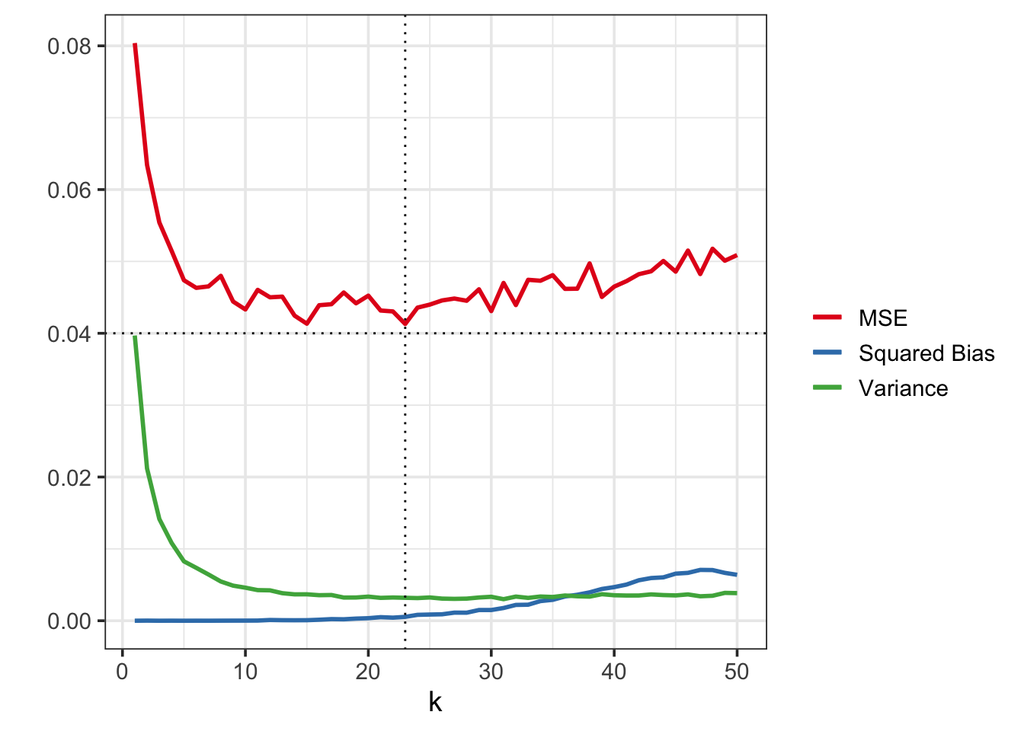

```r
theme_set(theme_bw(base_size = 14))
k_grid <- 1:50
B <- 2000
x0 <- 2.5
y0_hat <- y0 <- array(NA, dim = B)
MSE <- sq_bias_MSE <- var_MSE <- array(NA, dim = length(k_grid))
for (i in 1:length(k_grid)){
  for (b in 1:B){
    X <- runif(samp_size, xmin, xmax)
    Y <- rnorm(samp_size, fx(X), sigma)
    y0[b] <- rnorm(1, fx(x0), sigma)

    fit <- knnreg(as.data.frame(X), Y, k = k_grid[i])
    y0_hat[b] <- predict(fit, as.data.frame(x0))
  }
  sq_bias_MSE[i] <- (mean(y0_hat) - fx(x0))^2
  var_MSE[i] <- var(y0_hat)
  MSE[i] <- mean((y0_hat - y0)^2)
}

ggplot() +
  geom_line(aes(x = k_grid, y = sq_bias_MSE, col = 'Squared Bias'), size = 1) +
  geom_line(aes(x = k_grid, y = var_MSE, col = 'Variance'), size = 1) +
  geom_line(aes(x = k_grid, y = MSE, col = 'MSE'), size = 1) +
  geom_hline(aes(yintercept = sigma^2), lty = 3) +
  geom_vline(aes(xintercept = k_grid[which.min(MSE)]), lty = 3) +
  labs(x = 'k', y = '') +
  scale_color_brewer(name = "", palette = "Set1")
```

Remember that

$$\text{MSE} = \mathbb{E}[\{y_{0} - \hat{f}(x_{0})\}^{2}] = \text{Var}\{ \hat{f}(x_{0})\} + [\text{Bias}\{\hat{f}(x_{0})\}]^{2} + \sigma^2.$$

## Validation set approach

If we have a lot of data and can afford to leave some data out, a simple approach might be to use some randomly selected training samples to build the model, and then to evaluate the error on the leftout test data. This can be done when we want to evaluate a set of possible models (e.g. different polynomial degrees). Let’s split the data in two sets:

- the first one - *training set* - is used to fit all these models
- the second one - *validation set* - is used to estimate prediction error for model selection and to select the “best” model.

It is difficult to give a general rule on how to choose the number of observations in each of the three parts, as this depends on the signal-to- noise ratio in the data and the training sample size. A typical split might be $80\%$ for training, and $20\%$ validation.

Let us load and plot the data.

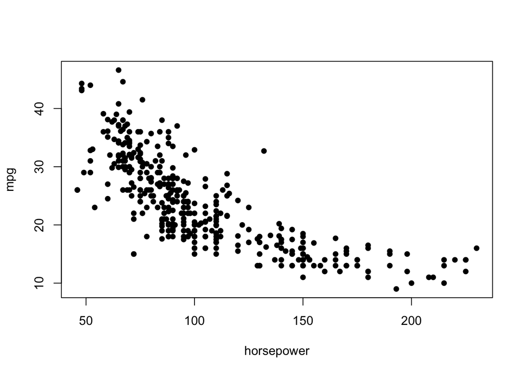

```r
rm(list=ls())
cols <- brewer.pal(9, "Set1")

plot(Auto$horsepower, Auto$mpg, pch = 16, xlab = 'horsepower', ylab = 'mpg')
```

Let us now create the splits of the data.

```r
n <- nrow(Auto)
set.seed(1234)
train_idx <- sample(1:n, floor(0.8 * n))
test_idx <- (1:n)[-train_idx]
```

And fit the different proposed models to the training data:

```r
d_max <- 12
val_err <- array(NA, dim = d_max)
for (d in 1:d_max){
  glm_fit <- glm(mpg ~ poly(horsepower, d), data = Auto[train_idx,])
  y_hat <- predict(glm_fit, newdata = Auto[test_idx,])
  val_err[d] <- mean((y_hat - Auto$mpg[test_idx])^2)
}
which.min(val_err)
```

```
[1] 2
```

Choose the model such that the validation error is minimum, i.e. $d = 2$.

## Cross validation

### Using the `glm` package

```r
library(glmnet)
library(boot)
glm_fit <- glm(mpg ~ horsepower, data = Auto) # a simple linear regression without specify the family

?cv.glm # this is the build in cv function for all glm models
cv.glm(Auto, glm_fit)$delta[1] # pretty slow (does not use formula (5.2) on page 180)
```

```
[1] 24.23151
```

Let’s write a simple function in order to use the magic formula that we saw in class for LOOCV, i.e.

$$CV_{(n)} = \frac{1}{n} \sum_{k=1}^n \text{Err}(y_i, \hat{y}_i)$$

```r
loocv_lm <- function(fit){
  h <- lm.influence(fit)$h # h is the leverage statistic, it is a vector with length n
  # h is also the diagonal of the hat matrix H = X(X'X)^(-1)X':
  # diag(X %*% solve(crossprod(X)) %*% t(X))
  return (mean((residuals(fit) / (1-h))^2))
}

loocv_lm(glm_fit)
```

```
[1] 24.23151
```

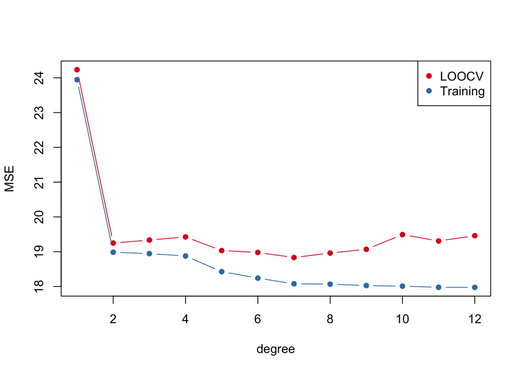

```r
loocv_error <- array(NA, dim = d_max)
MSE <- array(NA, dim = d_max)
for(d in 1:d_max){
  glm_fit <- glm(mpg ~ poly(horsepower, d), data = Auto)
  loocv_error[d] <- loocv_lm(glm_fit)
  MSE[d] <- mean(residuals(glm_fit)^2)
}
plot(1:d_max, loocv_error, type = "b", ylim = c(min(MSE), max(loocv_error)),
     pch = 16, xlab = 'degree', ylab = 'MSE', col = cols[1])
lines(1:d_max, MSE, pch = 16, type = "b", col = cols[2])
legend('topright', legend = c('LOOCV', 'Training'), col = cols[1:2], pch = 16)
```

$10$-fold cross validation

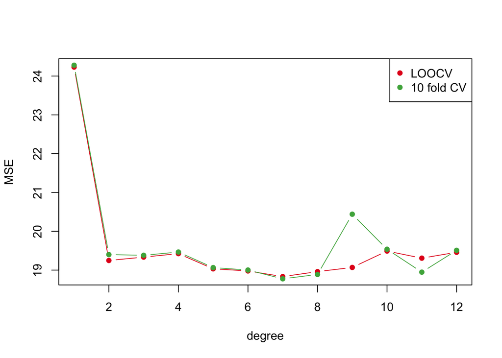

```r
cv10_error <- array(NA, dim = d_max)
for(d in 1:d_max){
  glm_fit <- glm(mpg ~ poly(horsepower, d), data = Auto)
  cv10_error[d] <- cv.glm(Auto, glm_fit, K = 10)$delta[1]
}
plot(1:d_max, loocv_error, type = "b", pch = 16, xlab = 'degree', ylab = 'MSE', col = cols[1])
lines(1:d_max, cv10_error, pch = 16, type = "b", col = cols[3])
legend('topright', legend = c('LOOCV', '10 fold CV'), col = cols[c(1,3)], pch = 16)
```

### Implemented from scratch

We might need to use cross validation in more complex models, when the `cv.glm()` function is not available. Let us implement it from scratch!

```r
K <- 10 # number of folds
folds <- cut(sample(1:n), breaks = K, labels = FALSE)
folds
```

```
  [1]  3  2  9  2  1  4  9  2  3  5  6  2  2  8 10  3  1  9  8  3  9  1  3
 [24]  2  6  2  7  1  5  5  9  5 10  6  4  6  9  2  4  8  6  1  3  6  8  2
 [47]  2  9  4  8  3  6  1  4  5  9  6  1  2  9  6  2  3  5  2 10  8  1  8
 [70]  1  9  7  1 10  7  2 10  1  7  6  7  7  9  6  9  6  7  2  8  8  9  2
 [93]  6  9  5  1  8  5  5  8  2  7  5  8  7  2  5  2  7  1  4  6  7  6  1
[116]  3  9  7  7 10  8  6  3  2  5 10  6  4  8 10  2  6  5  7  6 10  5  1
[139]  1  9  4  9 10  5 10  4 10  6  2  4  4  2  9  1  5  6  5  1  2  8  6
[162]  8  4  4  3  1  4  9 10  8  6  9  6  1  4  7  4  4  5  4  6  8  3  8
[185]  7  5  6  5  4  2  3  5  3  3  4  7  8  8  3  8  4  7  2  2  1 10  9
[208]  2  8  2  1  3  4  9  2  5  3  9  6  3  3  8  4  5  1  5  7  3 10  8
[231] 10  2  4  8 10 10  7  9  9  6  1  9  1  7  4  8  9  1 10 10  5  3  7
[254]  5 10  6  2  4  5  6  7  3 10  1  8  4  9  1  1 10  4  9 10  1  8  9
[277]  9  7  2  7  8  5  5  3  3  5  3  1  7  4  5  3  7  3 10  6  6  7  7
[300]  3 10  9  8 10  4  4  4  5  7  9  1 10  4  9 10  1  2  8  5  2  3  8
[323]  5  6  9  1  8 10 10  2  3  7  5  6  1  7 10  7  6  2  5  8  3 10  8
[346]  6  1 10  7 10  3  2  8  9  7  5  1  9  4  6  5  7  1  4  9  3  1  7
[369]  5  1  6  6 10  7  9  2  3  4  3 10  4  3 10  8  4  8  3  3  7 10  4
[392] 10
```

Look at the folds vector: each element corresponds to an observation and denotes the fold where that observation falls. We will iterate through the folds and take observations in that fold as test set, whereas all other observations are going to train the model.

Why did we use sample(1:n) in the call to the function `cut()`? This is very important!

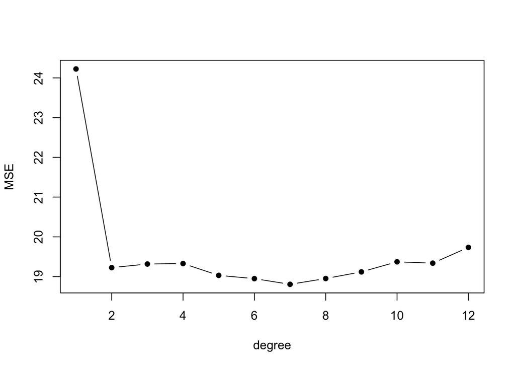

```r
cv_error <- array(NA, dim = c(K, d_max))
for (d in 1:d_max){
  for (i in 1:K){
    test <- which(folds == i)
    train <- which(folds != i)

    glm_fit <- glm(mpg ~ poly(horsepower, d), data = Auto[train,])
    cv_error[i,d] <- mean((Auto$mpg[test] - predict(glm_fit, newdata = Auto[test,]))^2)
  }
}
plot(1:d_max, colMeans(cv_error), type = "b", pch = 16, xlab = 'degree',
     ylab = 'MSE')
```

# Bootstrap

## Sample median

```r
rm(list=ls())
cols <- brewer.pal(9, "Set1")

n <- 200

set.seed(1234)
X <- rnorm(n, 2, 3)
```

1. Sample $n$ observations $(x_1^{(b)}, \dots, x_n^{(b)})$ **with replacement** from the original sample
2. Compute the median $\tilde{X}^{(b)}$

We then have a sample of estimates $(\tilde{X}^{(1)}, \dots, \tilde{X}^{(B)})$.

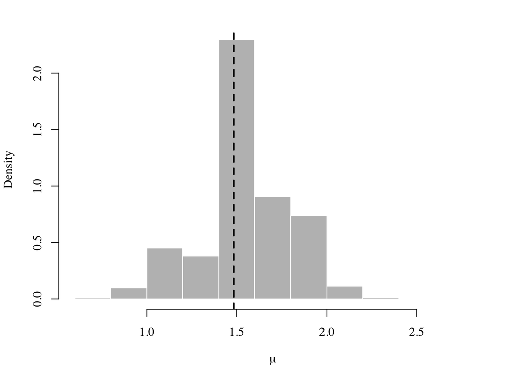

```r
B <- 5000
mu_boot <- array(NA, dim = B)
for (b in 1:B){
  idx_boot <- sample(1:n, n, replace = TRUE)
  X_boot <- X[idx_boot]
  mu_boot[b] <- median(X_boot)
}

xgrid <- seq(min(mu_boot), max(mu_boot), length.out = 100)
par(mar=c(4,4,2,2), family = 'serif')
hist(mu_boot, col = 'gray', border = 'white', probability = T, main = '', xlab = TeX("$\\mu"))
abline(v = median(X), lwd = 2, lty = 2)
```

## OLS estimator

We can do the same with the regression estimates! For example, in order to estimate the variability of a linear regression fit, we can repeatedly draw different samples from the training data, fit a linear regression to each new sample, and then examine the extent to which the resulting fits differ.

```r
rm(list=ls())
cols <- brewer.pal(9, "Set1")

n <- 200

set.seed(1234)
X <- rnorm(n, 2, 1)
Y <- - 1 + 2*X + rnorm(n, 0, 1)
```

1. Sample $n$ **pairs** $(x_1^{(b)}, y_1^{(b)}, \dots, x_n^{(b)}, y_n^{(b)})$ **with replacement** from the original sample
2. Compute the linear regression estimates $\hat{\beta}_0, \hat{\beta}_1$

We then have a sample of estimates $(\hat{\beta}_0^{(1)}, \hat{\beta}_1^{(1)}, \dots, \hat{\beta}_0^{(B)}, \hat{\beta}_1^{(B)})$.

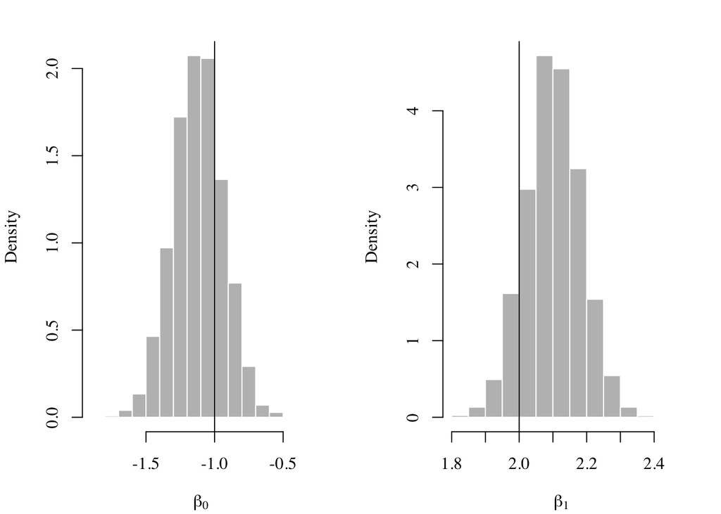

```r
B <- 5000
beta_0_boot <- array(NA, dim = B)
beta_1_boot <- array(NA, dim = B)
for (b in 1:B){
  idx_boot <- sample(1:n, n, replace = TRUE)
  fit <- lm(Y[idx_boot] ~ X[idx_boot])
  beta_0_boot[b] <- coef(fit)[1]
  beta_1_boot[b] <- coef(fit)[2]
}

par(mar=c(4,4,2,2), mfrow = c(1, 2), family = 'serif')
hist(beta_0_boot, col = 'gray', border = 'white', probability = T, main = '', xlab = TeX("$\\beta_0"))
abline(v = -1)
hist(beta_1_boot, col = 'gray', border = 'white', probability = T, main = '', xlab = TeX("$\\beta_1"))
abline(v = 2)
```

# Exercise 1

$$\begin{aligned}
&x_1, \dots, x_n \sim \text{Unif}(0, 10)
\\
&y_i \mid x_i \sim \mathcal{N}(\sin(x_i), 0.5)
\end{aligned}$$

Determine the optimal $k$ for k-NN regression applied to that data. Plot the result.